# Practical Machine Learning Project

Cara Johnson

November 9, 2017

### Data Summary

There are many devices that collect data on personal activity. Much analysis is dedicated to classifying what activity the user was performing, for example running or walking. The data for this project is from a study that sought to classify the manner in which users performed a paritular exercise. Class A means they performed a dumbbell lift correctly, while Classes B-E represent four different common mistakes. Data was collected from accelerometers placed on the user’s body and on their dumbbell.

The goal of this project is to take the training data set and build a model to predict the Class. The data for this project come from this source: http://web.archive.org/web/20161224072740/http:/groupware.les.inf.puc-rio.br/har.

Load in the data.

```r
#load data
training <- read.csv(url("https://d396qusza40orc.cloudfront.net/predmachlearn/pml-training.csv"), na.strings=c("NA",""))
testing <- read.csv(url("https://d396qusza40orc.cloudfront.net/predmachlearn/pml-testing.csv"), na.strings=c("NA",""))
#load relevant packages
library(caret)
library(rattle)
library(ggplot2)
library(randomForest)
```

### Implement cross validation

Split the training data set so that 70% of the data is used for training and 30% is used for validation.

```r
# split training set into training1 and validation sets
set.seed(3456)
inTrain <- createDataPartition(y=training$classe,p=0.7,list=FALSE)
training1 <- training[inTrain,]
validation <- training[-inTrain,]
```

### Clean the data

Remove variables that have nearly zero variance, variables with NA’s, and also the first six variables, which have no relevance to the analysis (x, user_name, raw_timestamp_part_1, raw_timestamp_part_2, cvtd_timestamp, num_window).

```r
# remove variables with near zero variance
nzv <- nearZeroVar(training1)
training1 <- training1[,-nzv]

# remove variables with NA's
TotalNA <- apply(training1, 2, function(x) {sum(is.na(x))})
training1 <- training1[, which(TotalNA == 0)]

# remove irrelevant col 1:6
training1 <- training1[,-c(1:6)]
```

### Model Selection

#### Model 1 - Decision Tree

First, fit a decision tree model and use cross validation to predict the accuracy and the out-of-sample error rate.

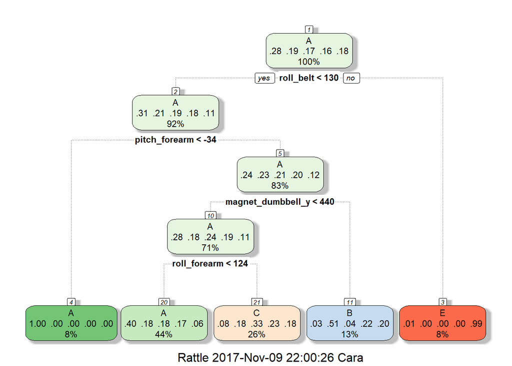

```r
set.seed(3456)
## model 1 - Decision Tree
modFit1 <- train(classe~.,data=training1,method="rpart",trControl=trainControl(method="cv"))
fancyRpartPlot(modFit1$finalModel)
```

```r
pred1 <- predict(modFit1,newdata=validation)
confusionMatrix(pred1,validation$classe)
```

```
## Confusion Matrix and Statistics
##
##           Reference
## Prediction    A    B    C    D    E
##          A 1505  458  474  418  155
##          B   32  393   31  188  147
##          C  133  288  521  358  306
##          D    0    0    0    0    0
##          E    4    0    0    0  474
##
## Overall Statistics
##
##                Accuracy : 0.4916
##                  95% CI : (0.4787, 0.5044)
##     No Information Rate : 0.2845
##     P-Value [Acc > NIR] : < 2.2e-16
##
##                   Kappa : 0.3363
##  Mcnemar's Test P-Value : NA
##
## Statistics by Class:
##
##                      Class: A Class: B Class: C Class: D Class: E
## Sensitivity            0.8990  0.34504  0.50780   0.0000  0.43808
## Specificity            0.6426  0.91614  0.77670   1.0000  0.99917
## Pos Pred Value         0.5000  0.49684  0.32441      NaN  0.99163
## Neg Pred Value         0.9412  0.85355  0.88198   0.8362  0.88755
## Prevalence             0.2845  0.19354  0.17434   0.1638  0.18386
## Detection Rate         0.2557  0.06678  0.08853   0.0000  0.08054
## Detection Prevalence   0.5115  0.13441  0.27290   0.0000  0.08122
## Balanced Accuracy      0.7708  0.63059  0.64225   0.5000  0.71862
```

Observe that the accuracy is 49.16% and, therefore the predicted out-of-sample error rate (1-accuracy) is 50.84%.

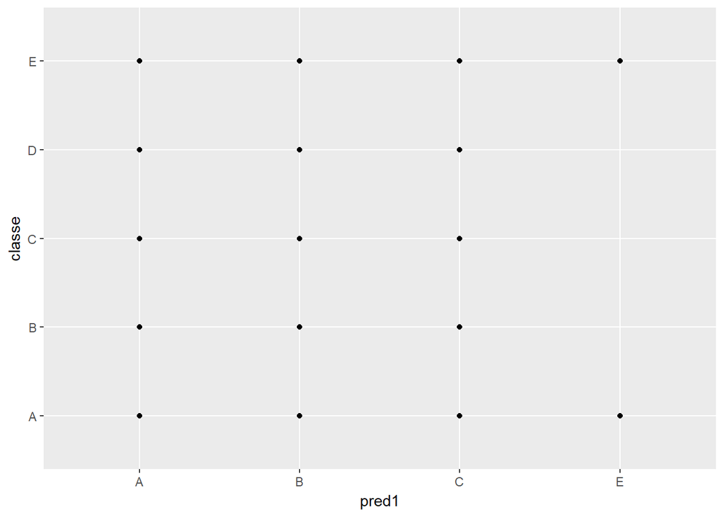

```r
qplot(pred1,classe,data=validation)
```

A plot of the predicted outcomes vs the actual outcomes further demonstrates the unsuitability of this model. This model will be discarded.

#### Model 2 - Random Forest

Next, fit a random forest model to the data. For the trainControl argument, use method=none in order to only fit one model to the entire training set.

```r
## model 2 - random forest
modFit2 <- train(classe~.,data=training1,trControl=trainControl(method="none"), method="parRF")
pred2 <- predict(modFit2,newdata=validation)
confusionMatrix(pred2,validation$classe)
```

```
## Confusion Matrix and Statistics
##
##           Reference
## Prediction    A    B    C    D    E
##          A 1674    8    0    0    0
##          B    0 1130    0    0    0
##          C    0    1 1020   11    1
##          D    0    0    6  953    1
##          E    0    0    0    0 1080
##
## Overall Statistics
##
##                Accuracy : 0.9952
##                  95% CI : (0.9931, 0.9968)
##     No Information Rate : 0.2845
##     P-Value [Acc > NIR] : < 2.2e-16
##
##                   Kappa : 0.994
##  Mcnemar's Test P-Value : NA
##
## Statistics by Class:
##
##                      Class: A Class: B Class: C Class: D Class: E
## Sensitivity            1.0000   0.9921   0.9942   0.9886   0.9982
## Specificity            0.9981   1.0000   0.9973   0.9986   1.0000
## Pos Pred Value         0.9952   1.0000   0.9874   0.9927   1.0000
## Neg Pred Value         1.0000   0.9981   0.9988   0.9978   0.9996
## Prevalence             0.2845   0.1935   0.1743   0.1638   0.1839
## Detection Rate         0.2845   0.1920   0.1733   0.1619   0.1835
## Detection Prevalence   0.2858   0.1920   0.1755   0.1631   0.1835
## Balanced Accuracy      0.9991   0.9960   0.9957   0.9936   0.9991
```

Observe that the accuracy is 99.52% and, therefore the predicted out-of-sample error rate (1-accuracy) is 0.48%.

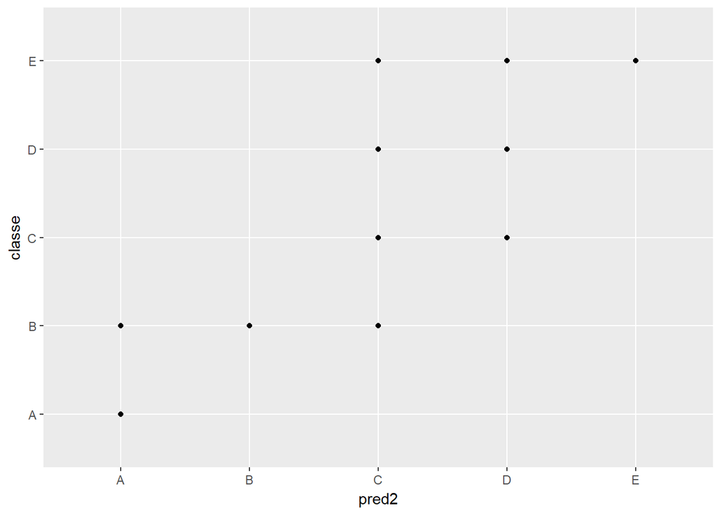

```r
qplot(pred2,classe,data=validation)
```

A plot of the predicted outcomes vs the actual outcomes demonstrates the high accuracy of this model. The random forest model will be selected.

### Prediction

Use the random forest model to predict the class for the testing data set.

```r
# predict classe for testing set
pred2final <- predict(modFit2,newdata=testing)
pred2final
```

```
##  [1] B A B A A E D B A A B C B A E E A B B B
## Levels: A B C D E
```